# Mentormind_Internship_2_barplots_Akshay_Gulhane

## Introduction

Employee retention strategies are integral to the success and well-being of a company. There are often many reasons why employees leave an organization, and in this project, I will explore some of the key drivers of employee attrition. Employee attrition measures how many workers have left an organization and is a common metric companies use to assess their performance. While turnover rates vary from industry to industry, the Bureau of Labor Statistics reported that among voluntary separations the overall turnover rate was 25% in 2020.

In this notebook, I will explore IBM's dataset on HR Analytics. The data consists of nearly 1,500 current and former employees with information related to their job satisfaction, work life balance, tenure, experience, salary, and demographic data. Below is a brief overview and summary statistics of the data.

```python
#Import the libraries
```

```python
import pandas as pd
import numpy as np
import matplotlib.pyplot as plt
from matplotlib import style
import seaborn as sns
import plotly
import plotly.express as px
```

```python
#Import the data
```

```python
hr_data = pd.read_csv(r'C:\Users\ASUS\Downloads\WA_Fn-UseC_-HR-Employee-Attrition.csv')
```

```python
hr_data.head()
```

|  | Age | Attrition | BusinessTravel | DailyRate | Department | DistanceFromHome | Education | EducationField | EmployeeCount | EmployeeNumber | ... | RelationshipSatisfaction | StandardHours | StockOptionLevel | TotalWorkingYears | TrainingTimesLastYear | WorkLifeBalance | YearsAtCompany | YearsInCurrentRole | YearsSinceLastPromotion | YearsWithCurrManager |
| --- | --- | --- | --- | --- | --- | --- | --- | --- | --- | --- | --- | --- | --- | --- | --- | --- | --- | --- | --- | --- | --- |
| 0 | 41 | Yes | Travel_Rarely | 1102 | Sales | 1 | 2 | Life Sciences | 1 | 1 | ... | 1 | 80 | 0 | 8 | 0 | 1 | 6 | 4 | 0 | 5 |
| 1 | 49 | No | Travel_Frequently | 279 | Research & Development | 8 | 1 | Life Sciences | 1 | 2 | ... | 4 | 80 | 1 | 10 | 3 | 3 | 10 | 7 | 1 | 7 |
| 2 | 37 | Yes | Travel_Rarely | 1373 | Research & Development | 2 | 2 | Other | 1 | 4 | ... | 2 | 80 | 0 | 7 | 3 | 3 | 0 | 0 | 0 | 0 |
| 3 | 33 | No | Travel_Frequently | 1392 | Research & Development | 3 | 4 | Life Sciences | 1 | 5 | ... | 3 | 80 | 0 | 8 | 3 | 3 | 8 | 7 | 3 | 0 |
| 4 | 27 | No | Travel_Rarely | 591 | Research & Development | 2 | 1 | Medical | 1 | 7 | ... | 4 | 80 | 1 | 6 | 3 | 3 | 2 | 2 | 2 | 2 |

5 rows × 35 columns

# EDA

```python
# Data Cleaning
# Exploratory Data Analysis (EDA)
```

```python
hr_data.info()
```

```
<class 'pandas.core.frame.DataFrame'>
RangeIndex: 1470 entries, 0 to 1469
Data columns (total 35 columns):
 #   Column                    Non-Null Count  Dtype
---  ------                    --------------  -----
 0   Age                       1470 non-null   int64
 1   Attrition                 1470 non-null   object
 2   BusinessTravel            1470 non-null   object
 3   DailyRate                 1470 non-null   int64
 4   Department                1470 non-null   object
 5   DistanceFromHome          1470 non-null   int64
 6   Education                 1470 non-null   int64
 7   EducationField            1470 non-null   object
 8   EmployeeCount             1470 non-null   int64
 9   EmployeeNumber            1470 non-null   int64
```

[output cut: 27 more lines]

```python
hr_data.isnull().sum()
```

```
Age                         0
Attrition                   0
BusinessTravel              0
DailyRate                   0
Department                  0
DistanceFromHome            0
Education                   0
EducationField              0
EmployeeCount               0
EmployeeNumber              0
EnvironmentSatisfaction     0
Gender                      0
HourlyRate                  0
JobInvolvement              0
JobLevel                    0
JobRole                     0
JobSatisfaction             0
MaritalStatus               0
MonthlyIncome               0
MonthlyRate                 0
NumCompaniesWorked          0
Over18                      0
OverTime                    0
PercentSalaryHike           0
PerformanceRating           0
RelationshipSatisfaction    0
StandardHours               0
StockOptionLevel            0
TotalWorkingYears           0
TrainingTimesLastYear       0
WorkLifeBalance             0
YearsAtCompany              0
YearsInCurrentRole          0
YearsSinceLastPromotion     0
YearsWithCurrManager        0
dtype: int64
```

```python
print("There are {} missing values in the data.".format(hr_data.isnull().sum().sum()))
```

```
There are 0 missing values in the data.
```

There are no missing values in dataset so we can proceed with visualization

# Visualizing metrics using barplots

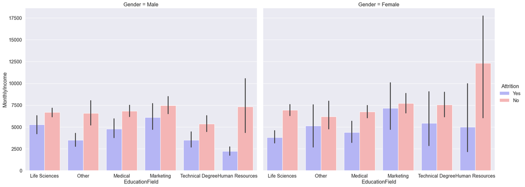

```python
# Barplot no 1 (Attrition of employees for EducationField v/s MonthlyIncome gender wise.)

sns.set(style='darkgrid', font_scale=1.3)
sns.catplot(x="EducationField", y="MonthlyIncome",hue="Attrition", col="Gender",
             data=hr_data, kind="bar",height=8, aspect=1.3, palette='bwr',col_order = ['Male','Female'])
```

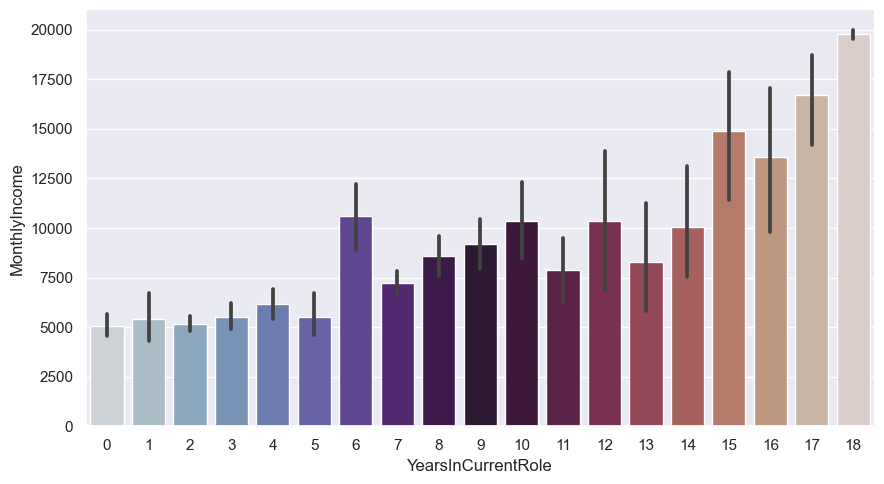

```python
# Barplot no 2 (Attrition of employees for YearsInCurrentRole v/s MonthlyIncome.)

sns.set(style='darkgrid', font_scale= 1)
sns.catplot(x="YearsInCurrentRole", y="MonthlyIncome",
             data=hr_data, kind="bar",height=5, aspect=1.8, palette='twilight')
```

CONCLUSION  
This barplot shows that the monthly income is positively corelated with the years of role experince as the experince increases the income also increases.

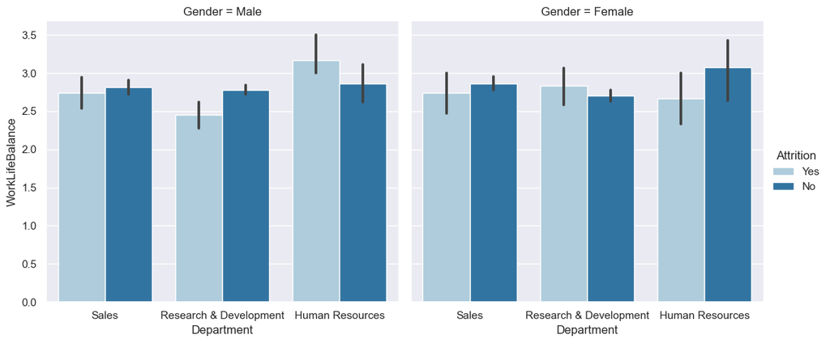

```python
# Barplot no 3 (Attrition of employees for Department v/s WorkLifeBalance gender wise.)

sns.set(style='darkgrid', font_scale= 1)
sns.catplot(x="Department", y="WorkLifeBalance",hue="Attrition", col="Gender",
             data=hr_data, kind="bar",height=5, aspect=1.1, palette='Paired',col_order = ['Male','Female'])
```

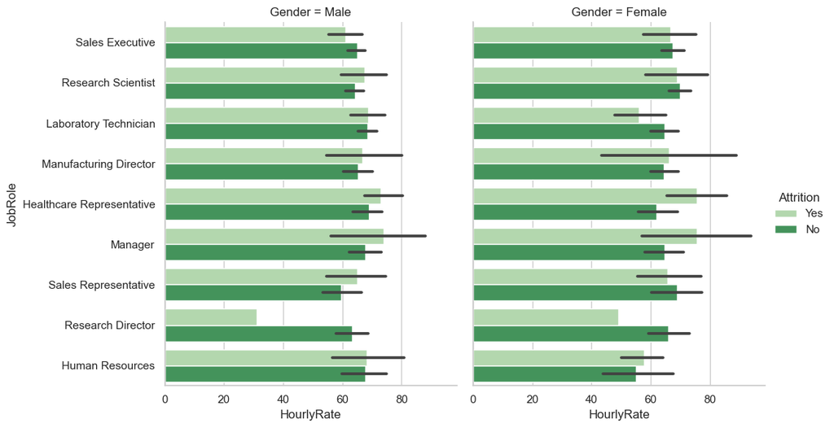

```python
# Barplot no 4 (Attrition of employees for HourlyRate v/s JobRole gender wise.)

sns.set(style='whitegrid', font_scale= 1)
sns.catplot(x="HourlyRate", y="JobRole",hue="Attrition", col="Gender",
             data=hr_data, kind="bar",height=6, aspect=.9, palette='Greens',col_order = ['Male','Female'])
```

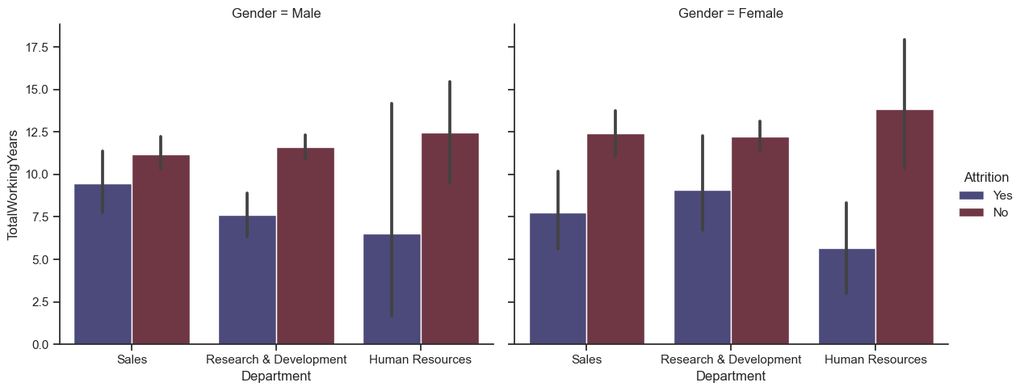

```python
# Barplot no 5 (Attrition of employees for Department v/s TotalWorkingYears gender wise.)

sns.set(style='ticks', font_scale= 1)
sns.catplot(x="Department", y="TotalWorkingYears",hue="Attrition", col="Gender",
             data=hr_data, kind="bar",height=5, aspect=1.2, palette='icefire',col_order = ['Male','Female'])
```

CONCLUSION  
In this barplot the attrition of male employees are mostly from sales department with total working years of 9 years and other side for female employees it is from Research and development department with total working years 8.5 years.

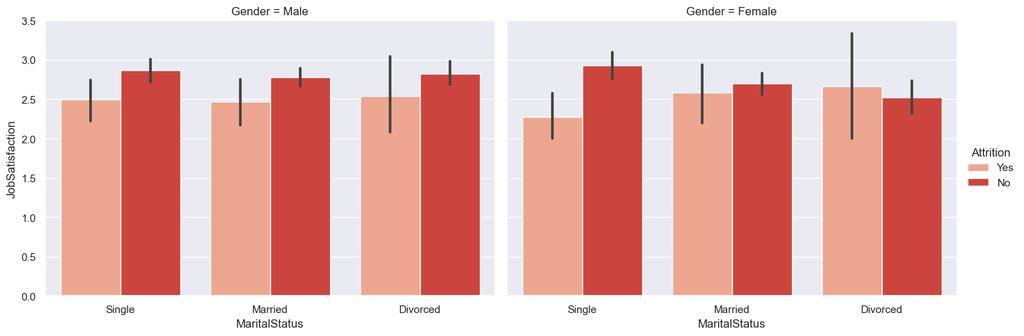

```python
# Barplot no 6 (Attrition of employees for MaritalStatus v/s JobSatisfaction gender wise.)

sns.set(style='darkgrid', font_scale= 1)
sns.catplot(x="MaritalStatus", y="JobSatisfaction",hue="Attrition", col="Gender",
             data=hr_data, kind="bar",height=5, aspect=1.4, palette='Reds',col_order = ['Male','Female'])
```

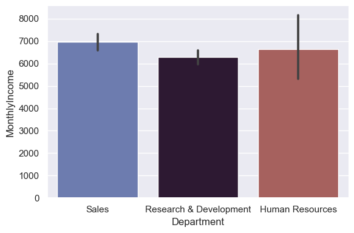

```python
# Barplot no 7 (Attrition of employees for Department v/s MonthlyIncome.)

sns.set(style='darkgrid', font_scale= 1)
sns.catplot(x="Department", y="MonthlyIncome",
             data=hr_data, kind="bar",height=4, aspect=1.5, palette='twilight')
```

CONCLUSION  
This barplot shows the highest monthly income is for sales department.

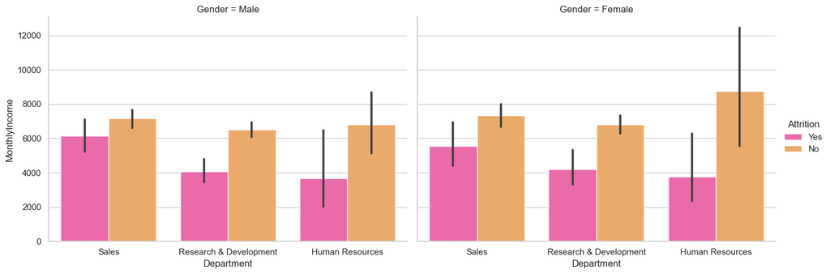

```python
# Barplot no 8 (Attrition of employees for Department v/s MonthlyIncome gender wise.)

sns.set(style='whitegrid', font_scale= 1)
sns.catplot(x="Department", y="MonthlyIncome",hue="Attrition", col="Gender",
             data=hr_data, kind="bar",height=5, aspect=1.4, palette='spring',col_order = ['Male','Female'])
```

CONCLUSION  
In this barplot the attrition of male employees are from sales department with monthlyincome 6000 and for female employees attrition is also from sales department with monthlyincome 5700.

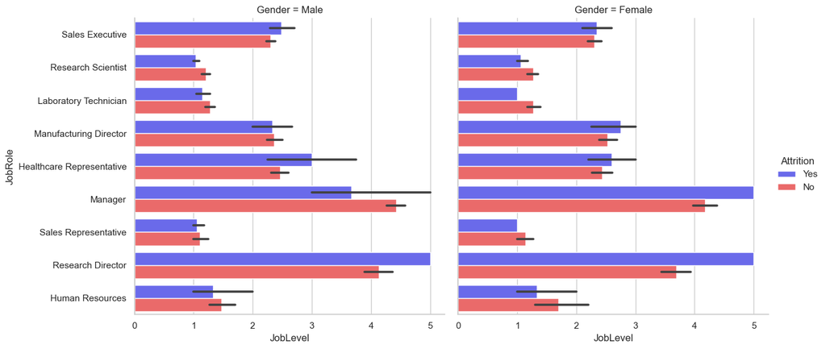

```python
# Barplot no 9 (Attrition of employees for JobLevel v/s JobRole gender wise.)

sns.set(style='whitegrid', font_scale= 1)
sns.catplot(x="JobLevel", y="JobRole",hue="Attrition", col="Gender",
             data=hr_data, kind="bar",height=6, aspect=1.1, palette='seismic',col_order = ['Male','Female'])
```

CONCLUSION  
In this barplot the attrition of male employees are from research director's job role whoes joblevel is 5 and also for female employees the attrition is from research director's role with same joblevel 5.

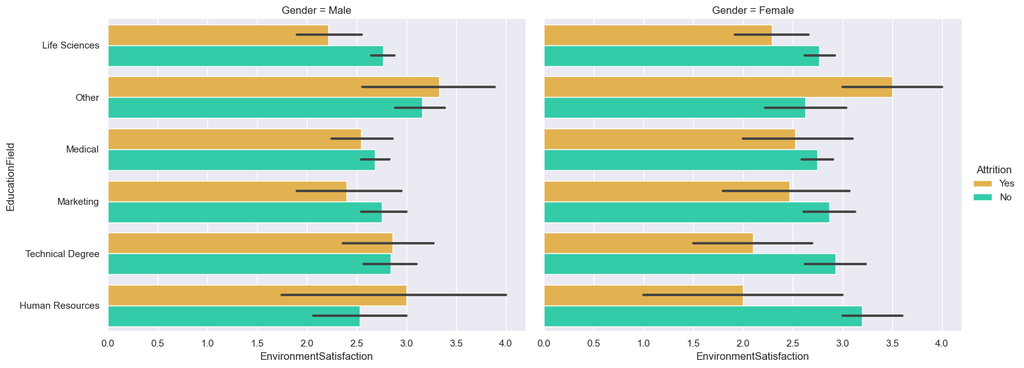

```python
# Barplot no 10 (Attrition of employees for EnvironmentSatisfaction v/s EducationField gender wise.)

sns.set(style='darkgrid', font_scale= 1)
sns.catplot(x="EnvironmentSatisfaction", y="EducationField",hue="Attrition", col="Gender",
             data=hr_data, kind="bar",height=6, aspect=1.3, palette='turbo_r',col_order = ['Male','Female'] )
```

CONCLUSION  
In this barplot the attrition of male employees are from other educational fields with environment satisfaction 3.2 and for female employees attrition it is from same other educationfield with environmentsatisfaction 3.5.

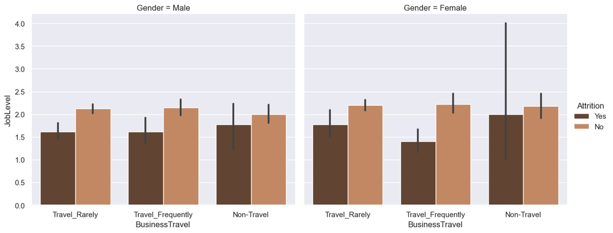

```python
# Barplot no 11 (Attrition of employees for BusinessTravel v/s JobLevel gender wise.)

sns.set(style='darkgrid', font_scale= 1)
sns.catplot(x="BusinessTravel", y="JobLevel",hue="Attrition", col="Gender",
             data=hr_data, kind="bar",height=5, aspect=1.2, palette='copper',col_order = ['Male','Female'] )
```

CONCLUSION  
In this barplot the attrition of male employees are non travellers whoes job levels are between 1.5 and 2 and female employees attrition are also non travelers whoes job levels are 2.

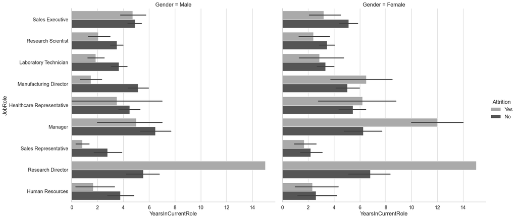

```python
# Barplot no 12 (Attrition of employees for YearsInCurrentRole v/s JobRole gender wise.)

sns.set(style='whitegrid', font_scale=1.3)
sns.catplot(x="YearsInCurrentRole", y="JobRole",hue="Attrition", col="Gender",
             data=hr_data, kind="bar",height=9, aspect=1.1, palette='binary',col_order = ['Male','Female'] )
```

CONCLUSION  
In this barplot the attrition of male employees are research directors playing same role from more than 14 years and also same for female employees research directors playing same role from more than 14 years.

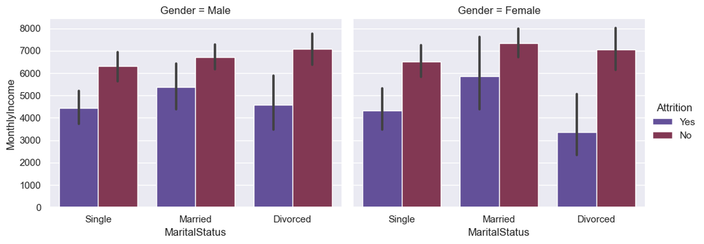

```python
# Barplot no 13 (Attrition of employees for MaritalStatus v/s MonthlyIncome gender wise.)

sns.set(style='darkgrid', font_scale= 1)
sns.catplot(x="MaritalStatus", y="MonthlyIncome",hue="Attrition", col="Gender",
             data=hr_data, kind="bar",height=4, aspect=1.3, palette='twilight',col_order = ['Male','Female'])
```

CONCLUSION  
This barplot shows the attrition of male employees which are married and have monthlyincome 5500 and also married females with monthlyincome 6000 have done attrition.

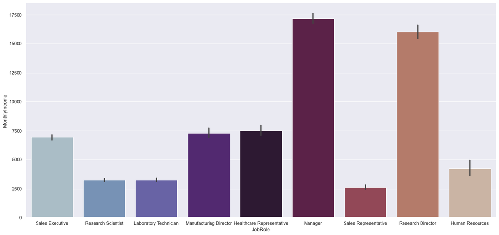

```python
# Barplot no 14 (Attrition of employees for JobRole v/s MonthlyIncome.)

sns.set(style='darkgrid', font_scale= 1)
sns.catplot(x="JobRole", y="MonthlyIncome",
             data=hr_data, kind="bar",height=8, aspect=2.1, palette='twilight')
```

CONCLUSION  
This barplot shows the highest monthly income is for Manager job role.

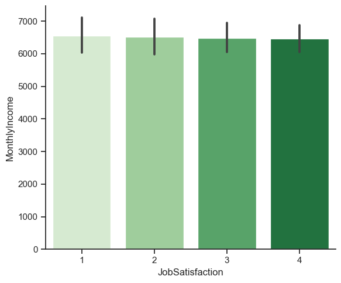

```python
# Barplot no 15 (Attrition of employees for JobSatisfaction v/s MonthlyIncome.)

sns.set(style='ticks', font_scale= 1)
sns.catplot(x="JobSatisfaction", y="MonthlyIncome",
             data=hr_data, kind="bar",height=5, aspect=1.2, palette='Greens')
```